# **College Basketball Prediction**

### Data Mining Final Project

**By: Mikul Muzumdar, Alec Plante, Johnson Feng, Leon Masin, Sumukh Shankar**

Data from https://www.kaggle.com/datasets/andrewsundberg/college-basketball-dataset

`GitHub repo: https://github.com/mikul109/College-Basketball-Prediction`

```r
# Dependencies:
library(tidyverse)
library(data.table)
library(classInt)
library(corrplot)
library(leaps)
library(pROC)
library(nnet)
library(e1071)
library(partykit)
library(class)
library(xgboost)
library(caret)
```

**Objective:**  
Use historical college basketball data to predict Regular Season Wins

**Steps:**  
I. Explore Dataset  
II. Data Preprocessing  
1. Cleaning  
2. Discretization  
3. Reducing Dimensionality  
III. Build and Test Classification Models  
1. Logistic Regression  
2. Support Vector Machines  
3. Decision Tree  
4. K-Nearest Neighbors  
5. XGBoost  
IV. Model Selection  
1. Comparing Accuracy  
2. Comparing AUC  
3. Conclusion

## **I. Data Exploration**

```r
# load data
cbb <- read.csv("https://raw.githubusercontent.com/mikul109/College-Basketball-Prediction/main/cbb.csv")
setDT(cbb)
```

Data from the 2013, 2014, 2015, 2016, 2017, 2018, and 2019 D1 College Basketball seasons

```r
dim(cbb)
```

```
[1] 2455   24
```

This data has 2455 rows and 24 columns.

Our Class Variable:  
`WPERC_b: team's win percentage (number of games won divided by number games played), in 4 bins`

Other Variables:  
`TEAM: The Division I college basketball school`  
`CONF: The Athletic Conference in which the school participates in`  
`G: Number of games played`  
`W: Number of games won`  
`ADJOE: Adjusted Offensive Efficiency (An estimate of the offensive efficiency (points scored per 100 possessions)`  
`a team would have against the average Division I defense)`  
`ADJDE: Adjusted Defensive Efficiency (An estimate of the defensive efficiency (points allowed per 100 possessions)`  
`a team would have against the average Division I offense)`  
`BARTHAG: Power Rating (Chance of beating an average Division I team)`  
`EFG_O: Effective Field Goal Percentage Shot`  
`EFG_D: Effective Field Goal Percentage Allowed`  
`TOR: Turnover Percentage Allowed (Turnover Rate)`  
`TORD: Turnover Percentage Committed (Steal Rate)`  
`ORB: Offensive Rebound Rate`  
`DRB: Offensive Rebound Rate Allowed`  
`FTR : Free Throw Rate (How often the given team shoots Free Throws)`  
`FTRD: Free Throw Rate Allowed`  
`2P_O: Two-Point Shooting Percentage`  
`2P_D: Two-Point Shooting Percentage Allowed`  
`3P_O: Three-Point Shooting Percentage`  
`3P_D: Three-Point Shooting Percentage Allowed`  
`ADJ_T: Adjusted Tempo (An estimate of the tempo (possessions per 40 minutes) a team would have against the team`  
`that wants to play at an average Division I tempo)`  
`WAB: Wins Above Bubble (The bubble refers to the cut off between making the NCAA March Madness Tournament and not making it)`  
`YEAR: Season`

```r
str(cbb)
```

```
Classes ‘data.table’ and 'data.frame':  2455 obs. of  24 variables:
 $ TEAM      : chr  "North Carolina" "Wisconsin" "Michigan" "Texas Tech" ...
 $ CONF      : chr  "ACC" "B10" "B10" "B12" ...
 $ G         : int  40 40 40 38 39 40 38 39 38 39 ...
 $ W         : int  33 36 33 31 37 29 30 35 35 33 ...
 $ ADJOE     : num  123 129 114 115 118 ...
 $ ADJDE     : num  94.9 93.6 90.4 85.2 86.3 96.2 93.7 90.6 89.9 91.5 ...
 $ BARTHAG   : num  0.953 0.976 0.938 0.97 0.973 ...
 $ EFG_O     : num  52.6 54.8 53.9 53.5 56.6 49.9 54.6 56.6 55.2 51.7 ...
 $ EFG_D     : num  48.1 47.7 47.7 43 41.1 46 48 46.5 44.7 48.1 ...
 $ TOR       : num  15.4 12.4 14 17.7 16.2 18.1 14.6 16.3 14.7 16.2 ...
 $ TORD      : num  18.2 15.8 19.5 22.8 17.1 16.1 18.7 18.6 17.5 18.6 ...
 $ ORB       : num  40.7 32.1 25.5 27.4 30 42 32.5 35.8 30.4 41.3 ...
 $ DRB       : num  30 23.7 24.9 28.7 26.2 29.7 29.4 30.2 25.4 25 ...
 $ FTR       : num  32.3 36.2 30.7 32.9 39 51.8 28.4 39.8 29.1 34.3 ...
 $ FTRD      : num  30.4 22.4 30 36.6 26.9 36.8 22.7 23.9 26.3 31.6 ...
 $ X2P_O     : num  53.9 54.8 54.7 52.8 56.3 50 53.4 55.9 52.5 51 ...
 $ X2P_D     : num  44.6 44.7 46.8 41.9 40 44.9 47.6 46.3 45.7 46.3 ...
 $ X3P_O     : num  32.7 36.5 35.2 36.5 38.2 33.2 37.9 38.7 39.5 35.5 ...
 $ X3P_D     : num  36.2 37.5 33.2 29.7 29 32.2 32.6 31.4 28.9 33.9 ...
 $ ADJ_T     : num  71.7 59.3 65.9 67.5 71.5 65.9 64.8 66.4 60.7 72.8 ...
 $ WAB       : num  8.6 11.3 6.9 7 7.7 3.9 6.2 10.7 11.1 8.4 ...
 $ POSTSEASON: chr  "2ND" "2ND" "2ND" "2ND" ...
 $ SEED      : int  1 1 3 3 1 8 4 1 1 1 ...
 $ YEAR      : int  2016 2015 2018 2019 2017 2014 2013 2015 2019 2017 ...
 - attr(*, ".internal.selfref")=<externalptr>
```

This shows the type of data and a preview of the data in each column for the dataset. Most of the variables are numeric, but there are also integers and character data types.

```r
head(cbb)
```

| TEAM | CONF | G | W | ADJOE | ADJDE | BARTHAG | EFG_O | EFG_D | TOR | TORD | ORB | DRB | FTR | FTRD | X2P_O | X2P_D | X3P_O | X3P_D | ADJ_T | WAB | POSTSEASON | SEED | YEAR |
| --- | --- | --- | --- | --- | --- | --- | --- | --- | --- | --- | --- | --- | --- | --- | --- | --- | --- | --- | --- | --- | --- | --- | --- |
| North Carolina | ACC | 40 | 33 | 123.3 | 94.9 | 0.9531 | 52.6 | 48.1 | 15.4 | 18.2 | 40.7 | 30.0 | 32.3 | 30.4 | 53.9 | 44.6 | 32.7 | 36.2 | 71.7 | 8.6 | 2ND | 1 | 2016 |
| Wisconsin | B10 | 40 | 36 | 129.1 | 93.6 | 0.9758 | 54.8 | 47.7 | 12.4 | 15.8 | 32.1 | 23.7 | 36.2 | 22.4 | 54.8 | 44.7 | 36.5 | 37.5 | 59.3 | 11.3 | 2ND | 1 | 2015 |
| Michigan | B10 | 40 | 33 | 114.4 | 90.4 | 0.9375 | 53.9 | 47.7 | 14.0 | 19.5 | 25.5 | 24.9 | 30.7 | 30.0 | 54.7 | 46.8 | 35.2 | 33.2 | 65.9 | 6.9 | 2ND | 3 | 2018 |
| Texas Tech | B12 | 38 | 31 | 115.2 | 85.2 | 0.9696 | 53.5 | 43.0 | 17.7 | 22.8 | 27.4 | 28.7 | 32.9 | 36.6 | 52.8 | 41.9 | 36.5 | 29.7 | 67.5 | 7.0 | 2ND | 3 | 2019 |
| Gonzaga | WCC | 39 | 37 | 117.8 | 86.3 | 0.9728 | 56.6 | 41.1 | 16.2 | 17.1 | 30.0 | 26.2 | 39.0 | 26.9 | 56.3 | 40.0 | 38.2 | 29.0 | 71.5 | 7.7 | 2ND | 1 | 2017 |
| Kentucky | SEC | 40 | 29 | 117.2 | 96.2 | 0.9062 | 49.9 | 46.0 | 18.1 | 16.1 | 42.0 | 29.7 | 51.8 | 36.8 | 50.0 | 44.9 | 33.2 | 32.2 | 65.9 | 3.9 | 2ND | 8 | 2014 |

The head function displays the first 6 rows of the data set.

```r
summary(cbb)
```

```
     TEAM               CONF                 G               W             ADJOE
 Length:2455        Length:2455        Min.   :15.00   Min.   : 0.00   Min.   : 76.6
 Class :character   Class :character   1st Qu.:30.00   1st Qu.:11.00   1st Qu.: 98.3
 Mode  :character   Mode  :character   Median :31.00   Median :16.00   Median :103.0
                                       Mean   :31.49   Mean   :16.28   Mean   :103.3
                                       3rd Qu.:33.00   3rd Qu.:21.00   3rd Qu.:108.0
                                       Max.   :40.00   Max.   :38.00   Max.   :129.1

     ADJDE          BARTHAG           EFG_O           EFG_D           TOR
 Min.   : 84.0   Min.   :0.0050   Min.   :39.20   Min.   :39.6   Min.   :11.90
 1st Qu.: 98.5   1st Qu.:0.2822   1st Qu.:47.75   1st Qu.:48.0   1st Qu.:17.30
 Median :103.5   Median :0.4750   Median :49.70   Median :50.0   Median :18.70
 Mean   :103.3   Mean   :0.4940   Mean   :49.81   Mean   :50.0   Mean   :18.76
 3rd Qu.:107.9   3rd Qu.:0.7122   3rd Qu.:51.90   3rd Qu.:52.0   3rd Qu.:20.10
 Max.   :124.0   Max.   :0.9842   Max.   :59.80   Max.   :59.5   Max.   :27.10

      TORD            ORB             DRB             FTR             FTRD
 Min.   :10.20   Min.   :15.00   Min.   :18.40   Min.   :21.60   Min.   :21.80
 1st Qu.:17.20   1st Qu.:27.10   1st Qu.:27.90   1st Qu.:32.40   1st Qu.:31.90
 Median :18.60   Median :29.90   Median :30.00   Median :35.80   Median :35.80
 Mean   :18.69   Mean   :29.88   Mean   :30.08   Mean   :35.99   Mean   :36.27
 3rd Qu.:20.10   3rd Qu.:32.60   3rd Qu.:32.20   3rd Qu.:39.50   3rd Qu.:40.20
 Max.   :28.50   Max.   :43.60   Max.   :40.40   Max.   :58.60   Max.   :60.70

     X2P_O          X2P_D           X3P_O           X3P_D          ADJ_T
 Min.   :37.7   Min.   :37.70   Min.   :24.90   Min.   :27.1   Min.   :57.20
 1st Qu.:46.5   1st Qu.:46.70   1st Qu.:32.50   1st Qu.:33.0   1st Qu.:65.70
 Median :48.7   Median :49.00   Median :34.40   Median :34.6   Median :67.80
 Mean   :48.8   Mean   :48.98   Mean   :34.41   Mean   :34.6   Mean   :67.81
 3rd Qu.:51.0   3rd Qu.:51.30   3rd Qu.:36.30   3rd Qu.:36.2   3rd Qu.:70.00
 Max.   :62.6   Max.   :61.20   Max.   :44.10   Max.   :43.1   Max.   :83.40

      WAB           POSTSEASON             SEED             YEAR
 Min.   :-25.200   Length:2455        Min.   : 1.000   Min.   :2013
 1st Qu.:-13.000   Class :character   1st Qu.: 5.000   1st Qu.:2014
 Median : -8.300   Mode  :character   Median : 9.000   Median :2016
 Mean   : -7.802                      Mean   : 8.803   Mean   :2016
 3rd Qu.: -3.150                      3rd Qu.:13.000   3rd Qu.:2018
 Max.   : 13.100                      Max.   :16.000   Max.   :2019
                                      NA's   :1979
```

The summary function of used on the data set shows the minimum and maximum number of each column, as well as the 1st quartile, 3rd quartile, the mean and the median.  
This function reveals some important information about our dataset.  
- Not every teams plays the same number of games like in many sports.  
- Not every team in this data set is ranked (no Seed value). This means that they did not make it to the tournament

```r
summary(cbb$YEAR)
```

```
   Min. 1st Qu.  Median    Mean 3rd Qu.    Max.
   2013    2014    2016    2016    2018    2019
```

Because COVID messed everything up after 2019, we will use data from 2013 to 2019

```r
summary(cbb$W)
```

```
   Min. 1st Qu.  Median    Mean 3rd Qu.    Max.
   0.00   11.00   16.00   16.28   21.00   38.00
```

The average number of wins is 16.28, Max = 38

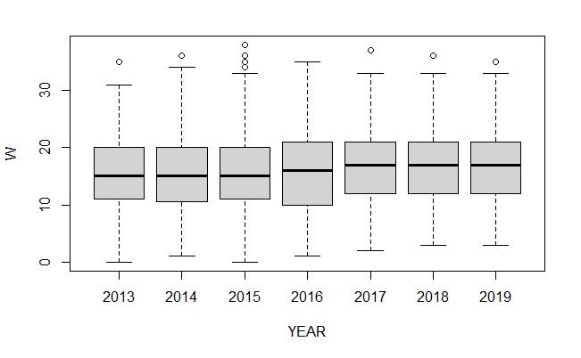

```r
boxplot(W~YEAR, data = cbb)
```

Distribution of wins based on the season. These seem to be pretty consistent from year to year

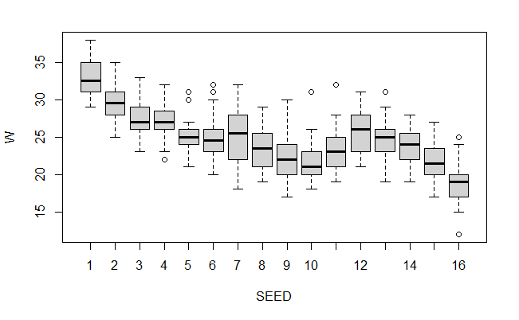

```r
boxplot(W~SEED, data = cbb)
```

This Boxplot shows the distribution of wins based on the seed value. Interestingly, the median number of wins does not always decrease with the seed number. For instance, the median wins for a 12th seed is higher than that for the 5th seed.

This could be due to more games. I am going to create a variable called win percentage and analyze that to see if there are any differences.

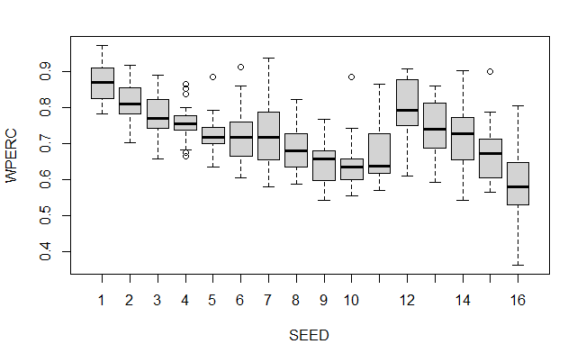

```r
cbb1<- cbb
cbb1$WPERC<-cbb1$W/cbb1$G

boxplot(WPERC~SEED, data = cbb1)
```

The same pattern continues. It seems to be even a little more exaggerated with the 12th seed. Lets view the numbers used in this graph

```r
by(cbb1$WPERC,cbb1$SEED,summary)
```

```
cbb1$SEED: 1
   Min. 1st Qu.  Median    Mean 3rd Qu.    Max.
 0.7838  0.8277  0.8717  0.8721  0.9118  0.9744
----------------------------------------------------------------------
cbb1$SEED: 2
   Min. 1st Qu.  Median    Mean 3rd Qu.    Max.
 0.7027  0.7832  0.8108  0.8120  0.8550  0.9189
----------------------------------------------------------------------
cbb1$SEED: 3
   Min. 1st Qu.  Median    Mean 3rd Qu.    Max.
 0.6571  0.7429  0.7714  0.7757  0.8235  0.8919
----------------------------------------------------------------------
cbb1$SEED: 4
   Min. 1st Qu.  Median    Mean 3rd Qu.    Max.
 0.6667  0.7391  0.7568  0.7590  0.7776  0.8649
----------------------------------------------------------------------
cbb1$SEED: 5
   Min. 1st Qu.  Median    Mean 3rd Qu.    Max.
 0.6364  0.7013  0.7183  0.7255  0.7446  0.8857
----------------------------------------------------------------------
cbb1$SEED: 6
   Min. 1st Qu.  Median    Mean 3rd Qu.    Max.
 0.6061  0.6667  0.7183  0.7228  0.7554  0.9143
----------------------------------------------------------------------
cbb1$SEED: 7
   Min. 1st Qu.  Median    Mean 3rd Qu.    Max.
 0.5806  0.6569  0.7183  0.7266  0.7864  0.9375
----------------------------------------------------------------------
cbb1$SEED: 8
   Min. 1st Qu.  Median    Mean 3rd Qu.    Max.
 0.5882  0.6364  0.6811  0.6847  0.7273  0.8235
----------------------------------------------------------------------
cbb1$SEED: 9
   Min. 1st Qu.  Median    Mean 3rd Qu.    Max.
 0.5429  0.5971  0.6571  0.6459  0.6811  0.7692
----------------------------------------------------------------------
cbb1$SEED: 10
   Min. 1st Qu.  Median    Mean 3rd Qu.    Max.
 0.5556  0.6000  0.6364  0.6430  0.6571  0.8857
----------------------------------------------------------------------
```

[output cut: 8 more lines]

```
cbb1$SEED: 13
   Min. 1st Qu.  Median    Mean 3rd Qu.    Max.
 0.5938  0.6875  0.7419  0.7411  0.8125  0.8611
----------------------------------------------------------------------
cbb1$SEED: 14
   Min. 1st Qu.  Median    Mean 3rd Qu.    Max.
 0.5429  0.6567  0.7273  0.7218  0.7659  0.9032
----------------------------------------------------------------------
cbb1$SEED: 15
   Min. 1st Qu.  Median    Mean 3rd Qu.    Max.
 0.5667  0.6061  0.6720  0.6723  0.7091  0.9000
----------------------------------------------------------------------
cbb1$SEED: 16
   Min. 1st Qu.  Median    Mean 3rd Qu.    Max.
 0.3636  0.5342  0.5806  0.5832  0.6466  0.8065
```

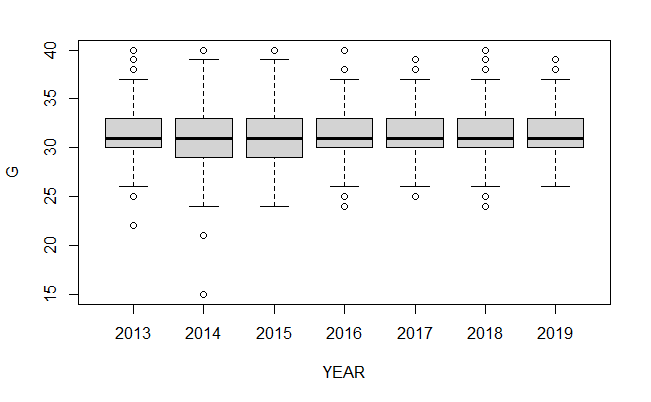

```r
boxplot(G~YEAR, data = cbb)
```

Same but for games. As you can see, there is a median of about 31 games per year

Win Percentage Per Conference:

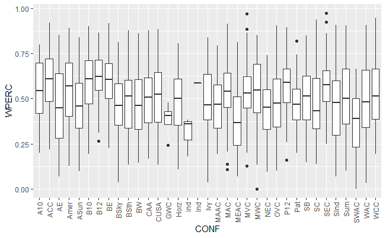

```r
ggplot(cbb1, aes(x=CONF, y=WPERC)) +
  geom_boxplot() + theme(axis.text.x = element_text(angle = 90, vjust = 0.5, hjust=1))
```

## Scatter Plots

### 1

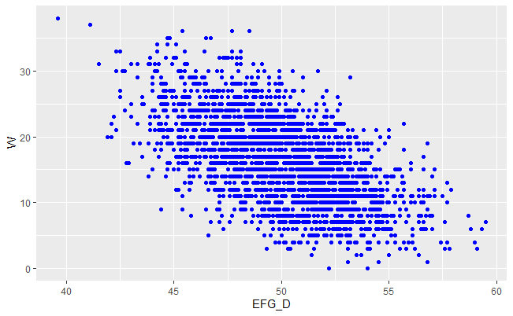

```r
ggplot(cbb) +
  geom_point(aes(EFG_D, W), colour = 'blue')
```

### 2

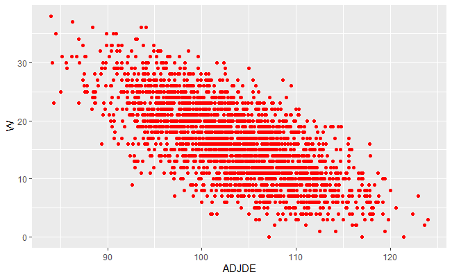

```r
ggplot(cbb) +
  geom_point(aes(ADJDE, W), colour = 'red')
```

### 3

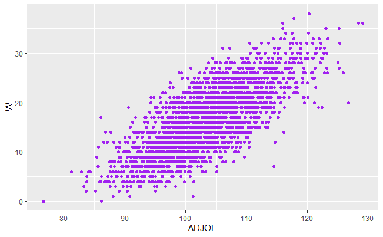

```r
ggplot(cbb) +
  geom_point(aes(ADJOE, W), colour = 'purple')
```

### 4

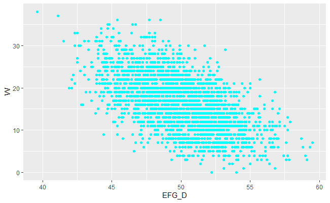

```r
ggplot(cbb) +
  geom_point(aes(EFG_D, W), colour = 'cyan')
```

### 5

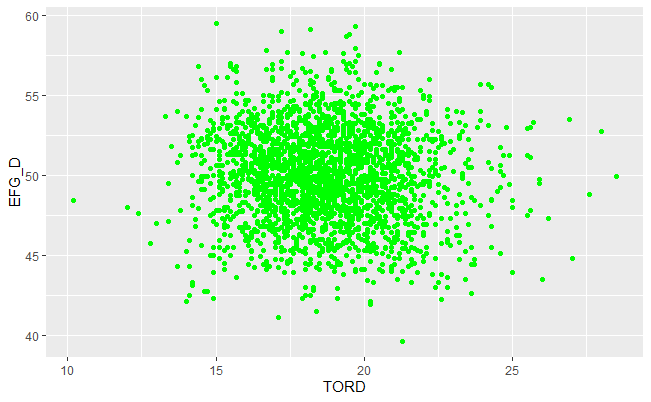

```r
ggplot(cbb) +
  geom_point(aes(TORD, EFG_D), colour = 'green')
```

### 6

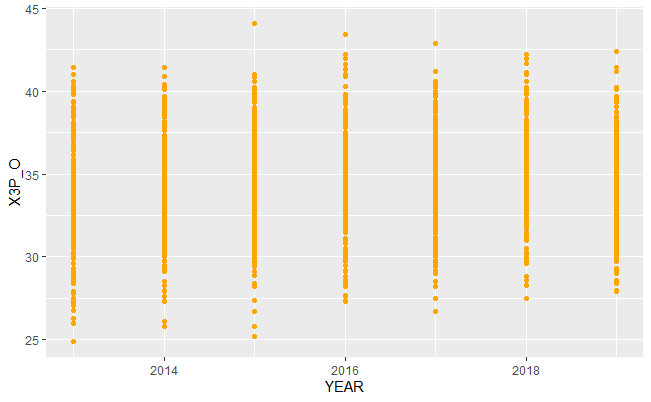

```r
ggplot(cbb) +
  geom_point(aes(YEAR, X3P_O), colour = 'orange')
```

## **II. Data Preprocessing**

## 1. Data Cleaning

```r
colSums(is.na(cbb))
```

```
      TEAM       CONF          G          W      ADJOE      ADJDE    BARTHAG      EFG_O
         0          0          0          0          0          0          0          0
     EFG_D        TOR       TORD        ORB        DRB        FTR       FTRD      X2P_O
         0          0          0          0          0          0          0          0
     X2P_D      X3P_O      X3P_D      ADJ_T        WAB POSTSEASON       SEED       YEAR
         0          0          0          0          0       1979       1979          0
```

The only N/A’s are in POSTEASON and SEED. Since they only apply to a small percentage of teams that made the tournament, we should drop these columns from our model data

```r
# drop POSTSEASON and SEED
cbb2 <- subset(cbb1, select=-c(POSTSEASON, SEED))
```

## 2. Discretization of the Class Variable

```r
# Our class variable is win percentage in the regular season, WPERC
# We will use equal frequency binning with 4 bins
nbins <- 4
bins <- classIntervals(cbb2$WPERC, nbins, style = 'quantile')
bins
```

```
style: quantile
       [0,0.3793103) [0.3793103,0.516129) [0.516129,0.6363636) [0.6363636,0.974359]
                 599                  615                  606                  635
```

```r
# assign bins to the WPERC variable
# assign variables as 1-4, representing the 4 bins
cbb2$WPERC_b <- cut(cbb2$WPERC, breaks = bins$brks, labels=as.character(1:nbins))
summary(cbb2$WPERC_b)
```

```
   1    2    3    4 NA's
 624  622  604  602    3
```

```r
# drops rows that did not fit into bins
cbb2<-cbb2[!(cbb2$WPERC_b=="NA"),]
summary(cbb2$WPERC_b)
```

```
  1   2   3   4
624 622 604 602
```

```r
# drop the WPERC variable that is not binned
cbb2<-subset(cbb2, select=-c(WPERC))
```

## 3. Reducing Dimensionality/Variable Selection

First, we should determine which variables outside of WPERC_b are independent.

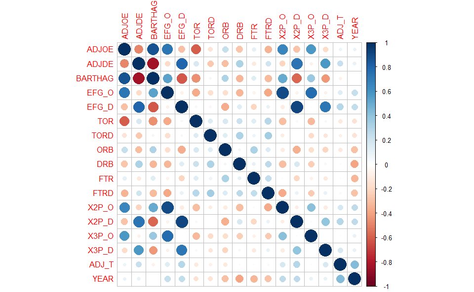

```r
# remove class and string variables
cbb_var <- subset(cbb2, select = -c(TEAM, CONF, WPERC_b))

# remove obvious dependent variables
cbb_var1 <- subset(cbb_var, select = -c(W, G, WAB))

# get correlations between each other
cbb_cor <- cor(cbb_var1)

# plot
corrplot(cbb_cor, method="circle")
```

Next, we should see which variables are correlated with the class variable.

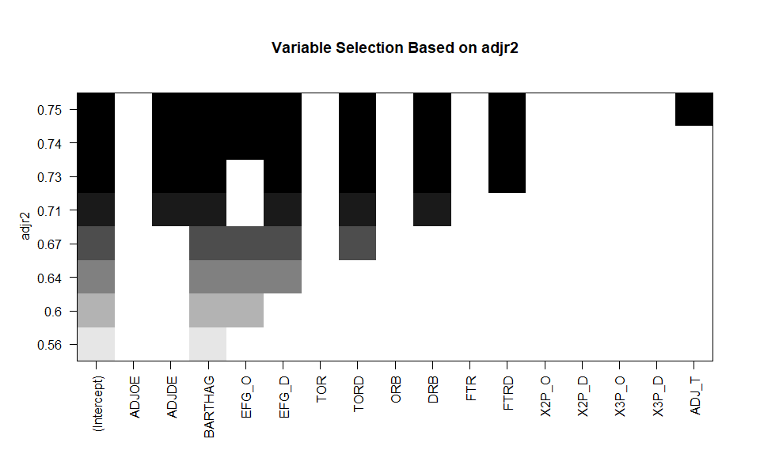

```r
# run linear regression and plot r^2
m1<-regsubsets(WPERC_b~.-TEAM-YEAR-CONF-G-W-WAB, data = cbb2)
plot(m1,scale="adjr2", main="Variable Selection Based on adjr2")
```

Conclusions:  
- Offensive stats such as ADJOE, 2P_O, and 3P_O are highly correlated with each other  
- Defensive stats such as ADJDE, EFG_D, 2P_D, and 3P_D are highly correlated with each other  
- BARTHAG is the variable most correlated with the class variable, WPERC_b  
- BARTHAG is most correlated with ADJOE and ADJDE

Final Variables, based on independence, correlation with WPERC_b, and general basketball knowledge:  
1. BARTHAG  
2. EFG_O  
3. EFG_D  
4. TORD  
5. DRB  
6. ADJOE  
7. ADJDE

## **III. Build and Test Classification Models**

Split into Train and Test datasets

```r
# convert class variable to factor
cbb2$WPERC_b <- as.factor(cbb2$WPERC_b)

# subset with needed variables
cbb_mod <- subset(cbb2, select=c(WPERC_b, BARTHAG, EFG_O, EFG_D, TORD, DRB, ADJOE, ADJDE))

# randomly split data 70/30
set.seed(123)
ind <- sample(2, nrow(cbb_mod), replace=TRUE, prob=(c(0.7,0.3)))
train_data <- cbb_mod[ind==1,]
test_data <- cbb_mod[ind==2,]
```

## 1. Logistic Regression

### Build Model

```r
# build model
cbb_glm <- multinom(WPERC_b ~ ., data = train_data)
# call model
summary(cbb_glm)
```

```
Call:
multinom(formula = WPERC_b ~ ., data = train_data)

Coefficients:
  (Intercept)    BARTHAG     EFG_O      EFG_D      TORD        DRB     ADJOE      ADJDE
2   -18.45607  -4.955706 0.2295149 -0.6992948 0.7226845 -0.3397819 0.3894408 0.03146114
3   -32.00708 -11.878371 0.4739238 -1.4509444 1.2666703 -0.6639462 0.7801433 0.04607848
4   -52.99390 -14.579179 0.7921134 -2.2431865 1.9583233 -1.0954771 1.0639764 0.18563468

Std. Errors:
  (Intercept)  BARTHAG      EFG_O      EFG_D       TORD        DRB      ADJOE      ADJDE
2    1.555555 1.011586 0.05005150 0.07264603 0.06224076 0.04290939 0.04064205 0.03337722
3    0.898843 1.080278 0.06277316 0.09620002 0.07636055 0.05606520 0.04335353 0.04315097
4    0.720938 1.219224 0.07644149 0.11915046 0.09176369 0.06909781 0.04738306 0.04865624

Residual Deviance: 2481.509
AIC: 2529.509
```

### Test Model

```r
# Make predictions
pred_classes_glm <- cbb_glm %>% predict(test_data)
# Model accuracy
mean(pred_classes_glm == test_data$WPERC_b)
```

```
[1] 0.6565517
```

```r
# Confusion matrix and stats
confusionMatrix(pred_classes_glm, test_data$WPERC_b)
```

```
Confusion Matrix and Statistics

          Reference
Prediction   1   2   3   4
         1 146  23   2   0
         2  35 112  51   7
         3   2  42  92  55
         4   0   3  29 126

Overall Statistics

               Accuracy : 0.6566
                 95% CI : (0.6207, 0.6911)
    No Information Rate : 0.2593
    P-Value [Acc > NIR] : < 2.2e-16

                  Kappa : 0.5424

 Mcnemar's Test P-Value : NA

Statistics by Class:

                     Class: 1 Class: 2 Class: 3 Class: 4
Sensitivity            0.7978   0.6222   0.5287   0.6702
Specificity            0.9539   0.8294   0.8203   0.9404
Pos Pred Value         0.8538   0.5463   0.4817   0.7975
Neg Pred Value         0.9332   0.8692   0.8464   0.8907
Prevalence             0.2524   0.2483   0.2400   0.2593
Detection Rate         0.2014   0.1545   0.1269   0.1738
Detection Prevalence   0.2359   0.2828   0.2634   0.2179
Balanced Accuracy      0.8758   0.7258   0.6745   0.8053
```

### ROC Curve

```r
# define object to plot and calculate AUC
predicted_glm <- factor(pred_classes_glm, ordered = TRUE)
rocobj_glm <- multiclass.roc(test_data$WPERC_b, predicted_glm)
```

```r
auc_glm <- round(auc(test_data$WPERC_b, predicted_glm),4)
```

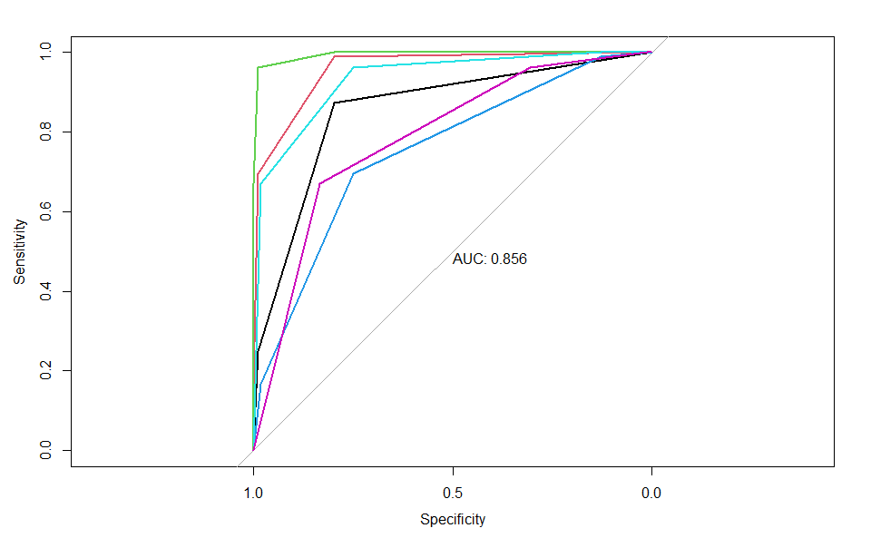

```r
# create ROC plot
# multi-class AUC as defined by Hand and Till
# One-vs-One approach, nC2 combinations of ROC curves
roc_glm <- rocobj_glm[['rocs']]
plot.roc(roc_glm[[1]], print.auc=TRUE)
sapply(2:length(roc_glm), function(i) lines.roc(roc_glm[[i]], col=i))
```

## 2. SVM

### Build Model

```r
cbb_svm = svm(WPERC_b ~ ., data = train_data, type="C-classification", kernal="radial", gamma=0.1, cost=10, scale = TRUE)

summary(cbb_svm)
```

```
Call:
svm(formula = WPERC_b ~ ., data = train_data, type = "C-classification", kernal = "radial",
    gamma = 0.1, cost = 10, scale = TRUE)


Parameters:
   SVM-Type:  C-classification
 SVM-Kernel:  radial
       cost:  10

Number of Support Vectors:  1247

 ( 217 403 213 414 )


Number of Classes:  4

Levels:
 1 2 3 4
```

### Plot Model

Predictors chosen: ADJOE vs ADJDE

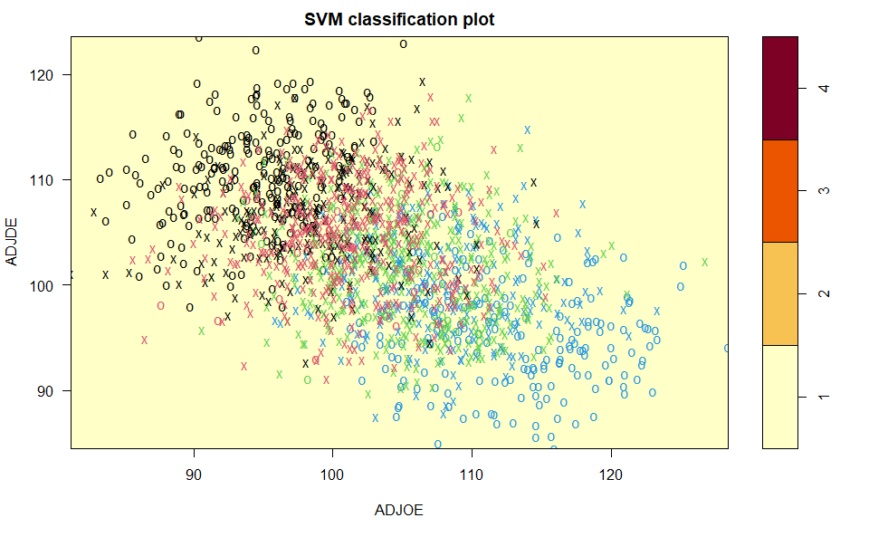

```r
plot(cbb_svm, data = train_data, ADJDE ~ ADJOE)
```

### Test Model

```r
# Make predictions
pred_classes_svm <- cbb_svm %>% predict(test_data)
# Model accuracy
mean(pred_classes_svm == test_data$WPERC_b)
```

```
[1] 0.6703448
```

```r
# Confusion matrix and stats
confusionMatrix(pred_classes_svm, test_data$WPERC_b)
```

```
Confusion Matrix and Statistics

          Reference
Prediction   1   2   3   4
         1 141  26   3   0
         2  38 110  37  10
         3   3  41 106  49
         4   1   3  28 129

Overall Statistics

               Accuracy : 0.6703
                 95% CI : (0.6348, 0.7045)
    No Information Rate : 0.2593
    P-Value [Acc > NIR] : < 2e-16

                  Kappa : 0.5608

 Mcnemar's Test P-Value : 0.04381

Statistics by Class:

                     Class: 1 Class: 2 Class: 3 Class: 4
Sensitivity            0.7705   0.6111   0.6092   0.6862
Specificity            0.9465   0.8440   0.8312   0.9404
Pos Pred Value         0.8294   0.5641   0.5327   0.8012
Neg Pred Value         0.9243   0.8679   0.8707   0.8954
Prevalence             0.2524   0.2483   0.2400   0.2593
Detection Rate         0.1945   0.1517   0.1462   0.1779
Detection Prevalence   0.2345   0.2690   0.2745   0.2221
Balanced Accuracy      0.8585   0.7276   0.7202   0.8133
```

### ROC Curve

```r
# define object to plot and calculate AUC
predicted_svm <- factor(pred_classes_svm, ordered = TRUE)
rocobj_svm <- multiclass.roc(test_data$WPERC_b, predicted_svm)
```

```r
auc_svm <- round(auc(test_data$WPERC_b, predicted_svm),4)
```

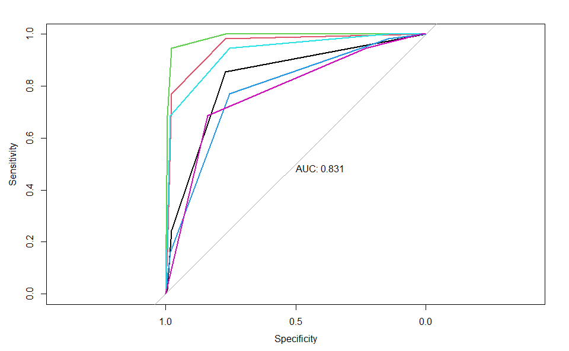

```r
# create ROC plot
# multi-class AUC as defined by Hand and Till
# One-vs-One approach, nC2 combinations of ROC curves
roc_svm <- rocobj_svm[['rocs']]
plot.roc(roc_svm[[1]], print.auc=TRUE)
sapply(2:length(roc_svm), function(i) lines.roc(roc_svm[[i]], col=i))
```

## 3. Decision Tree

### Build Model

```r
# build model
cbb_tree <- ctree(WPERC_b ~ ., data = train_data)

# call model
summary(cbb_tree)
```

```
   Length Class      Mode
1  57     constparty list
2  13     constparty list
3   5     constparty list
4   1     constparty list
5   3     constparty list
6   1     constparty list
7   1     constparty list
8   7     constparty list
9   1     constparty list
10  5     constparty list
11  1     constparty list
12  3     constparty list
13  1     constparty list
14  1     constparty list
```

[output cut: 43 more lines]

### Plot Model

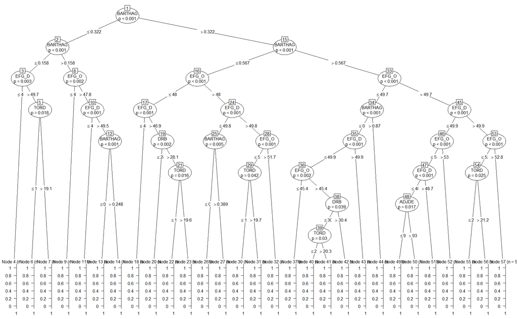

```r
plot(cbb_tree)
```

### Test Model

```r
# Make predictions
pred_classes_tree <- cbb_tree %>% predict(test_data)
# Model accuracy
mean(pred_classes_tree == test_data$WPERC_b)
```

```
[1] 0.5655172
```

```r
# Confusion matrix and stats
confusionMatrix(pred_classes_tree, test_data$WPERC_b)
```

```
Confusion Matrix and Statistics

          Reference
Prediction   1   2   3   4
         1 131  29   9   2
         2  41  85  51  21
         3  11  49  65  36
         4   0  17  49 129

Overall Statistics

               Accuracy : 0.5655
                 95% CI : (0.5285, 0.602)
    No Information Rate : 0.2593
    P-Value [Acc > NIR] : <2e-16

                  Kappa : 0.4204

 Mcnemar's Test P-Value : 0.3489

Statistics by Class:

                     Class: 1 Class: 2 Class: 3 Class: 4
Sensitivity            0.7158   0.4722  0.37356   0.6862
Specificity            0.9262   0.7927  0.82577   0.8771
Pos Pred Value         0.7661   0.4293  0.40373   0.6615
Neg Pred Value         0.9061   0.8197  0.80674   0.8887
Prevalence             0.2524   0.2483  0.24000   0.2593
Detection Rate         0.1807   0.1172  0.08966   0.1779
Detection Prevalence   0.2359   0.2731  0.22207   0.2690
Balanced Accuracy      0.8210   0.6324  0.59967   0.7816
```

### ROC Curve

```r
# define object to plot and calculate AUC
predicted_tree <- factor(pred_classes_tree, ordered = TRUE)
rocobj_tree <- multiclass.roc(test_data$WPERC_b, predicted_tree)
```

```r
auc_tree <- round(auc(test_data$WPERC_b, predicted_tree),4)
```

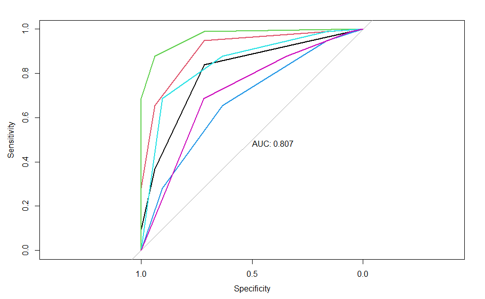

```r
# create ROC plot
# multi-class AUC as defined by Hand and Till
# One-vs-One approach, nC2 combinations of ROC curves
roc_tree <- rocobj_tree[['rocs']]
plot.roc(roc_tree[[1]], print.auc=TRUE)
sapply(2:length(roc_tree), function(i) lines.roc(roc_tree[[i]], col=i))
```

## 4. KNN

### Build Model

```r
# normalize
norm <-function(x) { (x -min(x))/(max(x)-min(x))}
cbb_norm <- as.data.frame(lapply(subset(cbb_mod, select=-WPERC_b), norm))

# split data 70/30
train_data_norm <- cbb_norm[ind==1,]
test_data_norm <- cbb_norm[ind==2,]

# extract classes
class_train <- train_data$WPERC_b
class_test <- test_data$WPERC_b

# build model
cbb_knn <- knn(train_data_norm, test_data_norm, class_train, k = nbins)

# call model
summary(cbb_knn)
```

```
  1   2   3   4
154 218 189 164
```

### Test Model

```r
# create the confusion matrix
tb_knn <- table(cbb_knn,class_test)

# check the accuracy
accuracy <- function(x){sum(diag(x)/(sum(rowSums(x))))}
accuracy(tb_knn)
```

```
[1] 0.5931034
```

```r
# Confusion matrix and stats
confusionMatrix(cbb_knn, test_data$WPERC_b)
```

```
Confusion Matrix and Statistics

          Reference
Prediction   1   2   3   4
         1 119  30   3   2
         2  58  98  46  16
         3   5  41  93  50
         4   1  11  32 120

Overall Statistics

               Accuracy : 0.5931
                 95% CI : (0.5563, 0.6291)
    No Information Rate : 0.2593
    P-Value [Acc > NIR] : < 2e-16

                  Kappa : 0.4578

 Mcnemar's Test P-Value : 0.02099

Statistics by Class:

                     Class: 1 Class: 2 Class: 3 Class: 4
Sensitivity            0.6503   0.5444   0.5345   0.6383
Specificity            0.9354   0.7798   0.8258   0.9181
Pos Pred Value         0.7727   0.4495   0.4921   0.7317
Neg Pred Value         0.8879   0.8383   0.8489   0.8788
Prevalence             0.2524   0.2483   0.2400   0.2593
Detection Rate         0.1641   0.1352   0.1283   0.1655
Detection Prevalence   0.2124   0.3007   0.2607   0.2262
Balanced Accuracy      0.7928   0.6621   0.6801   0.7782
```

### ROC Curve

```r
# define object to plot and calculate AUC
predicted_knn <- factor(cbb_knn, ordered = TRUE)
rocobj_knn <- multiclass.roc(test_data$WPERC_b, predicted_knn)
```

```r
auc_knn <- round(auc(test_data$WPERC_b, predicted_knn),4)
```

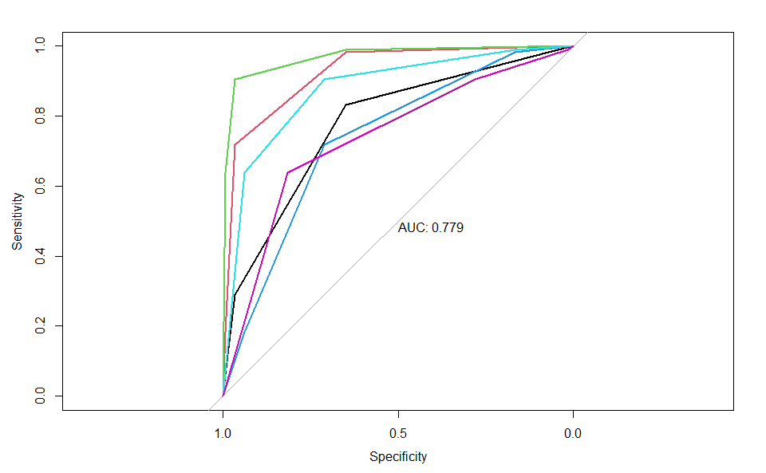

```r
# create ROC plot
# multi-class AUC as defined by Hand and Till
# One-vs-One approach, nC2 combinations of ROC curves
roc_knn <- rocobj_knn[['rocs']]
plot.roc(roc_knn[[1]], print.auc=TRUE)
sapply(2:length(roc_knn), function(i) lines.roc(roc_knn[[i]], col=i))
```

## 5. XGBoost

### Build Model

```r
# Create numeric labels with one-hot encoding
train_labs <- as.numeric(train_data$WPERC_b) - 1
test_labs <- as.numeric(test_data$WPERC_b) - 1

new_train <- model.matrix(~ . + 0, data = train_data[, -1])
new_test <- model.matrix(~ . + 0, data = test_data[, -1])

# Prepare matrices
xgb_train <- xgb.DMatrix(data = new_train, label = train_labs)
xgb_test <- xgb.DMatrix(data = new_test, label = test_labs)

# Set parameters(default)
params <- list(booster = "gbtree", objective = "multi:softprob", num_class = nbins, eval_metric = "mlogloss")

# Calculate # of folds for cross-validation
xgbcv <- xgb.cv(params = params, data = xgb_train, nrounds = 100, nfold = 5, showsd = TRUE, stratified = TRUE, print.every.n = 10, early_stop_round = 20, maximize = FALSE, prediction = TRUE)
# Function to compute classification error
classification_error <- function(conf_mat) {
  conf_mat = as.matrix(conf_mat)
  error = 1 - sum(diag(conf_mat)) / sum(conf_mat)
  return (error)
}

# Mutate xgb output to deliver hard predictions
xgb_train_preds <- data.frame(xgbcv$pred) %>% mutate(max = max.col(., ties.method = "last"), label = train_labs + 1)

# Examine output
head(xgb_train_preds)
```

|  | X1 | X2 | X3 | X4 | max | label |
| --- | --- | --- | --- | --- | --- | --- |
| 1 | 6.003704e-06 | 4.985585e-05 | 0.0010171999 | 0.9989269 | 4 | 4 |
| 2 | 9.169989e-07 | 5.304008e-06 | 0.0002272882 | 0.9997665 | 4 | 4 |
| 3 | 9.150863e-04 | 7.360183e-03 | 0.4949483275 | 0.4967764 | 4 | 4 |
| 4 | 2.889118e-06 | 1.043382e-05 | 0.0006777110 | 0.9993089 | 4 | 4 |
| 5 | 1.713407e-06 | 9.802925e-06 | 0.0001100456 | 0.9998784 | 4 | 4 |
| 6 | 1.563505e-05 | 1.891430e-04 | 0.0010469611 | 0.9987482 | 4 | 4 |

### Test Model

```r
# Confusion Matrix
xgb_conf_mat <- table(true = train_labs + 1, pred = xgb_train_preds$max)

# Model Accuracy
accuracy(xgb_conf_mat)
```

```
[1] 0.6039375
```

```r
# Confusion matrix and stats
confusionMatrix(factor(xgb_train_preds$max), factor(train_labs + 1))
```

```
Confusion Matrix and Statistics

          Reference
Prediction   1   2   3   4
         1 324  89  13   0
         2 106 208 111  15
         3  11 128 213 101
         4   0  17  93 298

Overall Statistics

               Accuracy : 0.6039
                 95% CI : (0.5804, 0.6271)
    No Information Rate : 0.2559
    P-Value [Acc > NIR] : < 2.2e-16

                  Kappa : 0.4718

 Mcnemar's Test P-Value : NA

Statistics by Class:

                     Class: 1 Class: 2 Class: 3 Class: 4
Sensitivity            0.7347   0.4706   0.4953   0.7198
Specificity            0.9207   0.8195   0.8150   0.9162
Pos Pred Value         0.7606   0.4727   0.4702   0.7304
Neg Pred Value         0.9101   0.8182   0.8297   0.9121
Prevalence             0.2554   0.2559   0.2490   0.2397
Detection Rate         0.1876   0.1204   0.1233   0.1726
Detection Prevalence   0.2467   0.2548   0.2623   0.2362
Balanced Accuracy      0.8277   0.6450   0.6552   0.8180
```

### ROC Curve

```r
# define object to plot and calculate AUC
predicted_xgb <- factor(xgb_train_preds$max, ordered = TRUE)
rocobj_xgb <- multiclass.roc(factor(train_labs + 1), predicted_xgb)
```

```r
auc_xgb <- round(auc(factor(train_labs + 1), predicted_xgb),4)
```

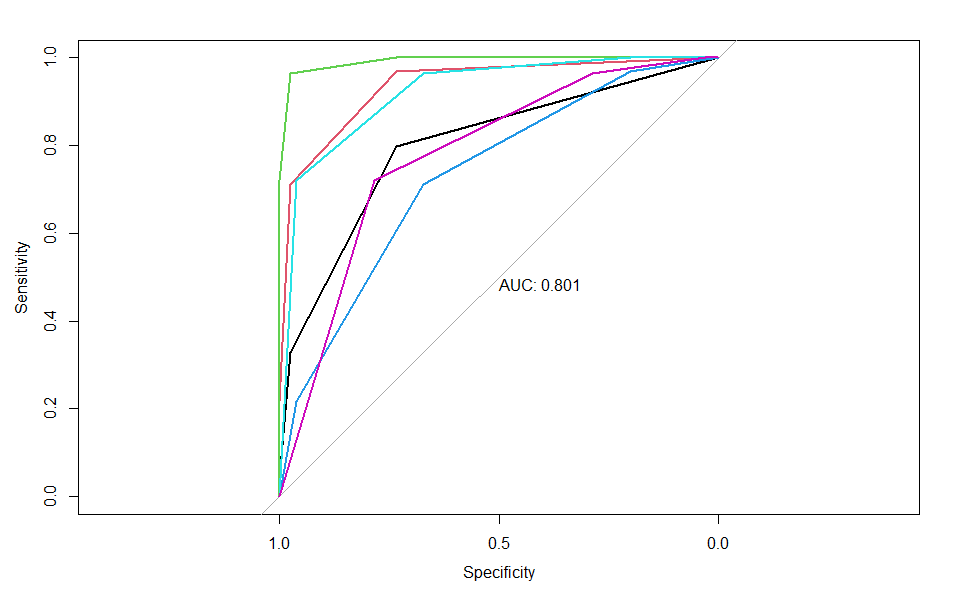

```r
# create ROC plot
# multi-class AUC as defined by Hand and Till
# One-vs-One approach, nC2 combinations of ROC curves
roc_xgb <- rocobj_xgb[['rocs']]
plot.roc(roc_xgb[[1]], print.auc=TRUE)
sapply(2:length(roc_xgb), function(i) lines.roc(roc_xgb[[i]], col=i))
```

## **IV. Model Selection**

### Comparing Accuracy

```r
cat('MEAN ACCURACY:',
paste0('Logistic Regression: ', mean(pred_classes_glm == test_data$WPERC_b)),
paste0('Support Vector Machines: ', mean(pred_classes_svm == test_data$WPERC_b)),
paste0('Decision Tree: ', mean(pred_classes_tree == test_data$WPERC_b)),
paste0('K-Nearest Neighbors: ', accuracy(tb_knn)),
paste0('XGBoost: ', accuracy(xgb_conf_mat)),
sep = '\n')
```

```
MEAN ACCURACY:
Logistic Regression: 0.656551724137931
Support Vector Machines: 0.670344827586207
Decision Tree: 0.56551724137931
K-Nearest Neighbors: 0.593103448275862
XGBoost: 0.603937463810075
```

### Comparing AUC

```r
cat('AUC:',
paste0('Logistic Regression: ', auc_glm),
paste0('Support Vector Machines: ', auc_svm),
paste0('Decision Tree: ', auc_tree),
paste0('K-Nearest Neighbors: ', auc_knn),
paste0('XGBoost: ', auc_xgb),
sep = '\n')
```

```
AUC:
Logistic Regression: 0.8556
Support Vector Machines: 0.8312
Decision Tree: 0.8071
K-Nearest Neighbors: 0.7789
XGBoost: 0.8007
```

### Conclusions

- All models perform okay, with ~0.60 mean accuracy, and ~0.80 AUC  
- This is expected given how unpredictable college basketball is, and since advanced stats do not directly  
predict wins, as shown in the variable selection section.  
- SVM has the highest mean accuracy, with Logistic Regression performing slightly worse  
- Logistic Regression has the best AUC, with SVM slightly lower  
- The best model is between SVM and Logistic Regression.